# MICB425_Portfolio

#### Exercise 3

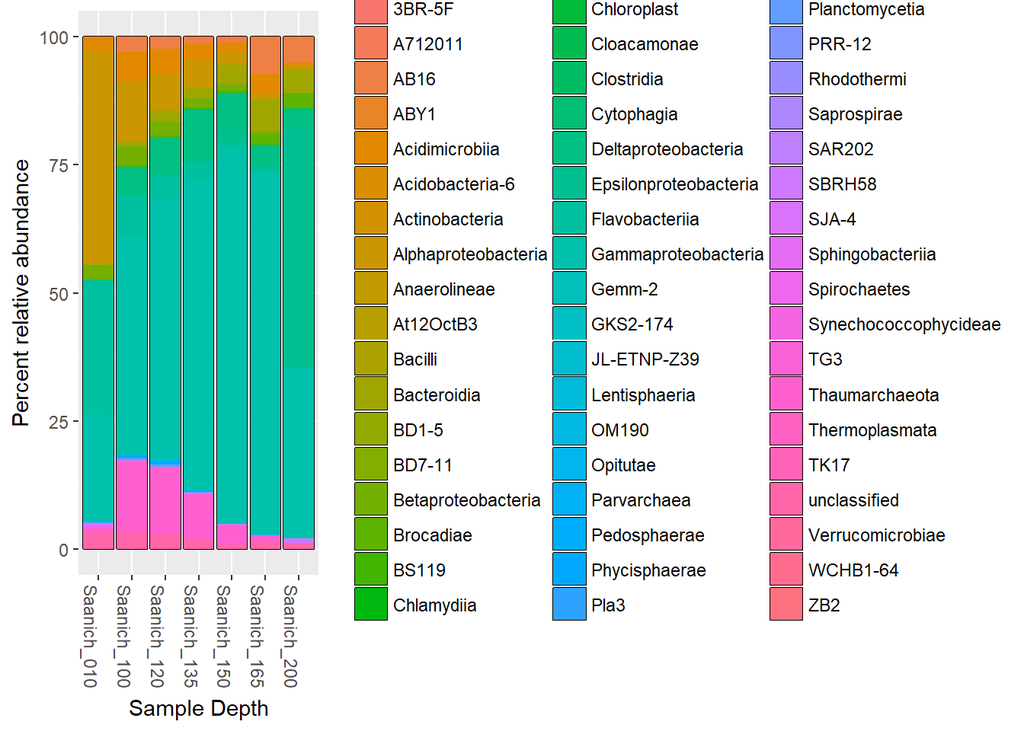

```r
plot_bar(physeq_percent, fill="Class") +
  geom_bar(aes(fill=Class), stat="identity") +
  labs(x="Sample Depth", y="Percent relative abundance")
```

#### Exercise 4

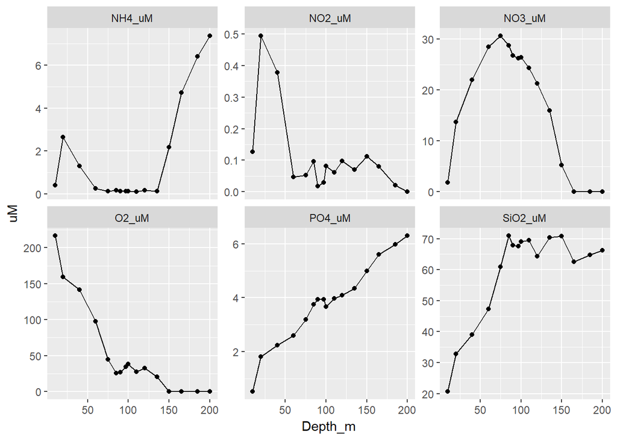

```r
metadata %>%
  gather(Nutrient, uM, NH4_uM, NO2_uM, NO3_uM, O2_uM, PO4_uM, SiO2_uM) %>% #Put all the desired data into a single column
  ggplot(aes(x=Depth_m, y=uM))+
  geom_point() +
  geom_line() + #Do both point and lines for the graph
  facet_wrap(~Nutrient, scales="free_y") +
  theme(legend.position="none")
```

## Module 01 Origins and Earth Systems

### Evidence worksheet 01

[Whitman *et al* 1998](https://www.ncbi.nlm.nih.gov/pmc/articles/PMC33863/)

#### Learning objectives

Describe the numerical abundance of microbial life in relation to ecology and biogeochemistry of Earth systems.

#### General questions

- What were the main questions being asked?
  - What is the total amount of prokaryotes on Earth and how much C/N/P do they contain?
  - How does the carbon in prokaryotes impact global biogeochemical models like the carbon cycle?
  - What is the diversity/mutation rate due to the number of prokaryotes?
  - What is the abundance of prokaryotic life in various habitats on Earth?
- What were the primary methodological approaches used?  
  Estimates of cell density for various environments extrapolated out to the global-biotic number of cells. They used literature to find the values to use for each of the environments.
- Summarize the main results or findings.  
  The total carbon taken up by prokaryotes is 60-100% of the total carbon taken up by plants and prokaryotes contain 10-fold more nutrients than plants. Also, the highest cellular productivity is found in the open ocean, therefore mutations and other rare genetic events are more likely to appear in marine populations than others. Finally, the subsurface-turnover time is far longer than found in other ecosystems.
- Do new questions arise from the results?  
  A few examples of new questions are as follows:
  - What is the cause and effect of the extraordinary long turnover time in subsurface prokaryotes?
  - How should species definitions be defined in context of prokaryotes vs. eukaryotes
  - How does the population of bacteria compare to that of archaea?
  - How does global climate change impact these estimates?
- Were there any specific challenges or advantages in understanding the paper (*e.g.* did the authors provide sufficient background information to understand experimental logic, were methods explained adequately, were any specific assumptions made, were conclusions justified based on the evidence, were the figures or tables useful and easy to understand)?  
  The assumptions regarding population density were well described, and the extrapolations to the whole global-biome populations seem justified, but there were some calculations that did not make sense. Specifically, the carbon content, efficiency, and turnover time calculations seemed to use values that did not have supporting evidence. Also, there were so many assumptions that it made it hard to truly follow what was really true or simply a hypothetical. The tables were laid out really well though, with all values displayed and not just the *total* values for each biome.

### Evidence Worksheet 02

#### Learning Objectives:

Comment on the emergence of microbial life and the evolution of Earth systems

#### Specific Questions:

*Indicate the key events in the evolution of Earth systems at each approximate moment in the time series. If times need to be adjusted or added to the timeline to fully account for the development of Earth systems, please do so.*

Hadean  
4.6 GA: Solar system formed, inner planets received water vapor and carbon 4.5 GA: Moon formed and gave Earth spin and tilt, day/night cycle, and seasons  
4.5 GA - 4.1 GA: High levels of CO2 increased temperature during times of the weak early sun.  
4.4 GA: Zircon formation: oldest mineral  
4.4 GA - 4.1 GA: meteorite impacts  
4.1 GA: Evidence of life in zircon and from carbon isotopes  
4 GA: Oldest rock: Acasta gneiss and evidence of plate subduction

Archaean  
3.8 GA: Existence of life: from sedimentary rocks and methanogenesis  
3.5 GA: Microfossils and stromatolites present  
3.5 GA - 2.7GA: Cyanobacteria photosynthesize  
2.7 GA: Great oxidation event: responsible for glaciation

Proterozoic  
2.5 GA - 1.5 GA: red rock beds observed: evidence of oxidation  
1.7 GA: Eukaryotes appear  
1.1 GA: Snowball Earth occurs

Phanerozoic  
540 MA: Cambrian explosion: increased diversity of life and larger organisms  
Land plants observed  
250 MA: Permian extinction: 95% species extinct  
Gigantism of organisms  
65 MA: Cretaceous/Paleogene Extinction

```
+ Archean
```

Atmosphere was filled with CH4 to keep the Earth warm still. As photosynthesis evolved, some O2 was present

```
+ Precambrian

+ Proterozoic
```

O2 reacted with atmospheric methane to produce CO2 This caused a net decrease in greenhouse gas effects, making earth cold and leading to glaciation. Oxygen on Earth started oxidizing iron into banded iron formations, seen in sedimentary rock.

```
- Phanerozoic
```

Increased oxygenation of the atmosphere Plants started to evolve and can be seen on Earth. Coal deposits developed as organisms died in extinctions and were stored in sediments There was the occasional glaciation periods

### Evidence Worksheet 03 “The Anthropocene”

[Waters et al. 2016] (https://www.ncbi.nlm.nih.gov/pubmed/26744408)

#### Learning objectives:

- Evaluate human impacts on the ecology and biogeochemistry of Earth systems.

#### General Questions:

- *What were the main questions being asked?*

How has humanity affected antrhopogenic markers of functional changes in the Earth system, and how is the Anthropocene distinguished from the Holocene?

- *What were the primary methodological approaches used?*

They reviewed various lines of evidence to track stratigraphic signatures over time. Some of the markers they investigated were standard epoch markers like ice core NO3, Temperatures, CO2 and methane, but they also used novel markers specific to human activity like Plutonium deposition, and concrete and plastic production. They also looked at vertebrate extinction rates.

- *Summarize the main results or findings.*

The stratigraphic signatures they discusses are either completely novel with respect to the Holocene or they are quantitatively outside the range of variation of the Holocene, plus they are accelerating. The exact boundary of the Anthropocene still needs to be figured out but should use their evidence to assist in the decision.

- *Do new questions arise from the results?*

Is it helpful to formalize the Anthropocene, or is it better to leave it as an informal, albeit solidly founded, geological time term, as the Precambrian and Tertiary currently are.

- *Were there any specific challenges or advantages in understanding the paper (e.g. did the authors provide sufficient background information to understand experimental logic, were methods explained adequately, were any specific assumptions made, were conclusions justified based on the evidence, were the figures or tables useful and easy to understand)?*

There was no methods section, so how the data was being collected was a challenge to follow. It looks like they used references for all of the data, but there are so many references that it makes it hard to validate their findings.

### Problem set 01

#### Learning objectives:

Describe the numerical abundance of microbial life in relation to the ecology and biogeochemistry of Earth systems.

#### Specific questions:

- What are the primary prokaryotic habitats on Earth and how do they vary with respect to their capacity to support life? Provide a breakdown of total cell abundance for each primary habitat from the tables provided in the text.

**Aquatic -** The majority of prokaryotic life in aquatic environments is found in the open ocean. They have a short turnover time and therefore a high cellular productivity, which means that mutations and other rare genetic events are most likely to occur here than other habitats.

Total abundance: 1.180x10^29

**Soil -** Major reservoir of organic carbon; prokaryotes are essential in soil decomposition

Total abundance: 2.556 x 10^29

**Subsurface -** Major habitat for prokaryotes, with most of the subsurface biomass supported by organic matter deposited from the surface.

Total abundance: 3.8 x 10^30

- What is the estimated prokaryotic cell abundance in the upper 200 m of the ocean and what fraction of this biomass is represented by marine cyanobacterium including Prochlorococcus? What is the significance of this ratio with respect to carbon cycling in the ocean and the atmospheric composition of the Earth?

Upper 200m of the ocean: 3.6x10^28 Density: 5x10^5 cells/mL

Fraction represented by cyanobacterium including Prochlorococcus:

4x10^4 cells/ml/5x10^5 cells x 100 = 8%

Marine cyanobacterium such as Prochlorococcus produce their own energy from sunlight via photosynthesis, which in the process produces oxygen while fixing carbon. Despite only being 8% of the prokaryotic cell abundance in the upper 200m, they are responsible for approximately 50% of the oxygen in the atmosphere and contribute greatly to carbon cycling as demonstrated by their quick turnover time and resulting 8.2 x 10^29 cells/year

- What is the difference between an autotroph, heterotroph, and a lithotroph based on information provided in the text?

Autotrophs: in this text are bacteria that produce their own food, primarily using energy from the sun. As a result, these are prokaryotes that are often found on surface environments that are able to receive some amount of sunlight. They are <10% of upper layer marine prokaryotes. However, they form the majority of prokaryotes in soil and subsurface? Thus, they are defined as primarily land-dwelling organisms. âSelf-nourishingâ, fix inorganic carbon (CO2) â Biomass

Heterotrophs: make up the majority of prokaryotic organisms with the majority, assimilate organic carbon. Of those found below 200m, they are defined as the most abundant sea-dwelling organisms.

Lithotrophs: are subsurface prokaryotes that use a different method of energy generation. They are defined as mysterious, primarily found in subsurface environments, and are scarcer than other types of prokaryotes. Use inorganic substrates.

- Based on information provided in the text and your knowledge of geography what is the deepest habitat capable of supporting prokaryotic life? What is the primary limiting factor at this depth?

The Mariana Trench is the deepest part of the ocean, and we know that it is an environment that supports prokaryotic life, although at this depth, there is nearly no light reaching it as well. Therefore, it is the deepest habitat known to support life. Because the paper has deduced that subsurface sediments below the water layer also contains prokaryotes, we could make the argument that the deepest habitat to host prokaryotic life would be the subsurface sediment layer of the Trench. Subsurface environments on land may contain prokaryotes further below that of the Mariana Trench. However, not much is currently known about life existing below these depths, due to challenges in retrieving uncontaminated samples from these areas. The text talks about how in subsurface environments, the limited carbon nutrition available to these organisms means that the majority are metabolically inactive or non-viable. However, evidence shows that metabolic activity is on par with that of surface prokaryotes. Because most of the carbon nutrient availability is gained from the surface, the primary limiting factor would be the transfer of carbon nutrients from surface to deeper subsurface environments, which logically decreases the deeper you go.

- Subsurface (marine=10,994 m -> 10.9 km deep? + can go down another 4-5 km depending on temperature) = deepest habitat, subsurface: limiting factor is temperature:
- Change in temperature as getting deeper is about 22 ËC/km
- Based on information provided in the text your knowledge of geography what is the highest habitat capable of supporting prokaryotic life? What is the primary limiting factor at this height?

Prokaryotes have been found in in the atmosphere at altitudes as high as 57-77 km. Mount Everest (8,848 meters, 8.8 km) is the highest geographical location on Earth, and therefore would technically be the highest habitat capable of supporting prokaryotic life. Is it capable of supporting prokaryotic life? Primary limiting factors at this height include temperature. Some prokaryotes, psychrophiles, have adapted to such low temperatures. Nutrients are also limited at high altitude. Less atoms are found in the upper atmosphere and thus less material is available to compose the building blocks of life. This would result in slower growth. UV radiation as well as pressure are limiting to life at high altitudes because they can damage cells.

- Based on estimates of prokaryotic habitat limitation, what is the vertical distance of the Earthâs biosphere measured in km?

Lower range:  
* Mariana Trench is 10,994 meter deep, but the lower limit is much deeper since it includes subsurface sediments, which is about 4.5km deeper.

Upper limit: * Mount Everest 8,848 m high, but the upper limit is much higher if it includes atmosphere as an âhabitatâ.

Vertical distance of the Earthâs biosphere: 19.84 km + 4.5km = 24km (+ potential atmosphere)

- How was annual cellular production of prokaryotes described in Table 7 column four determined? (Provide an example of the calculation)

Annual cellular production, in cells/year X 10^29 was calculated with the following formula: Cells/year = Population Size * (365 / (turnover time [days]))

- What is the relationship between carbon content, carbon assimilation efficiency and turnover rates in the upper 200m of the ocean? Why does this vary with depth in the ocean and between terrestrial and marine habitats?

Carbon content along with carbon assimilation efficiency determine the upperbound limit on the turnover rates seen in the upper 200m of the ocean. This varies with depth in the ocean, and between terrestrial and marine habitats because the abundance of carbon in each habitat is different.

Carbon efficiency: 20% 20 fg of C on avg in prokaryotic cell (20 fg/cell) ~20 = 20*10^-30 Pg/cell (3.6 X 10^28 cells) x (10^-30 Pg/cell) = 0.72 Pg C in marine heterotrophs

```
51 Pg cell/year      85% consumed = 43 Pg C
(43 Pg cell/year)/2.88 Pg/year = 14.9 turnovers/year, 1 turnover every 24.1 days
[365 days /14.9 turnovers = ~24 days / turnover]
```

- How were the frequency numbers for four simultaneous mutations in shared genes determined for marine heterotrophs and marine autotrophs given an average mutation rate of 4 x 10<sup>-7</sup> per DNA replication? (Provide an example of the calculation with units. Hint: cell and generation cancel out)

((365d/y)*(24h/d)/(((4*10<sup>-7)</sup>4 mutations/cell))*(8.2*10^29 cells/y)=(h/4 simultaneous mutations)

```
= 4x10^-7 mutations/generation
```

- Given the large population size and high mutation rate of prokaryotic cells, what are the implications with respect to genetic diversity and adaptive potential? Are point mutations the only way in which microbial genomes diversify and adapt?

A large mutation rate means that there is a great potential for multiple point mutations in a single replication. This allows for quick adaptation by creating a more diverse pool of mutants to be selected from. Genetic diversity will be extremely high when small scale changes to sequence are considered and long term “species” level biodiversity will mostly be determined by competition and environmental pressures. Horizontal gene transfer can allow new genes to proliferate in a microbial community assuming the gene is successful in the organism is “born” in.

- What relationships can be inferred between prokaryotic abundance, diversity, and metabolic potential based on the information provided in the text?

High abundance allows for high diversity by increasing the potential for mutations and simultaneous mutations. Metabolic potential is dependent on both abundance and diversity. Diversity determines the pool of available genes to be used in metabolic pathways and abundance determines the magnitude of the effect of these pathways.

### Problem set_02 Microbial Engines

#### Learning objectives:

Discuss the role of microbial diversity and formation of coupled metabolism in driving global biogeochemical cycles.

#### Specific Questions:

- What are the primary geophysical and biogeochemical processes that create and sustain conditions for life on Earth? How do abiotic versus biotic processes vary with respect to matter and energy transformation and how are they interconnected?

Geophysical - Geothermal processes, diagenesis, tectonics, erosion, mountain building, atmosphere  
Biogeochemical - Microbial catalyzed redox reactions (photosynthesis, fermentation, etc.)

The abiotic processes recycle matter from the earth to be used by biotic processes, which then use the matter to create energy and pass the products of their metabolism on to other biotic processes to use. The final end products, like CO2 and CH4, are released into the atmosphere to be recycled by the abiotic processes.

- Why is Earth’s redox state considered an emergent property?

The feedback between microbial evolution and biogeochemical processes has created Earth’s current redox state. Every process is linked and interconnected.

- How do reversible electron transfer reactions give rise to element and nutrient cycles at different ecological scales? What strategies do microbes use to overcome thermodynamic barriers to reversible electron flow?

Cycles can be oxidative or reductive, yet they all feed the end products into new reactions, creating cycles. Strategies: - methanogenic Archaea reduce CO2 with H2, but require high enough H+ tension for the reaction to proceed forward, otherwise it will proceed in reverse. Certain species of methanogens utilize the unfavourable reverse reaction through the synergistic cooperation with H2 consuming sulfate reducers.

- Using information provided in the text, describe how the nitrogen cycle partitions between different redox niches and microbial groups. Is there a relationship between the nitrogen cycle and climate change?

The only biological process that makes N2 available for biomolecule synthesis is nitrogen fixation, a reductive process that transforms N2 to NH4+. This process is catalyzed by nitrogenase and inhibited by O2. O2 present - NH4+ oxidized to nitrate in two-stage pathway requiring one group of microbes to oxidize ammonia to NO2-, which is subsequently oxidized to NO3- by a different niche of microbes. O2 absent - a different microbial group uses NO2- and NO3- as e- acceptors in the anaerobic oxidation of organic matter, ultimately forming N2.  
There is a link between the nitrogen cycle and climate change, for without the available nitrogen provided by the nitrogen cycle life would not have been able to evolve the pathways required for oxidative phosphorylation, which has driven major geological climate changes throughout earth’s history.

- What is the relationship between microbial diversity and metabolic diversity and how does this relate to the discovery of new protein families from microbial community genomes?

While horizontal gene flow has distributed many families of genes, there still exists metabolic diversity amongst microbial communities. For example, chlorophyll-based photosynthesis is restricted to bacteria while methanogenesis is restricted to archaea. The discovery of new protein families is increasing linearly with the number of new genomes sequenced.

- On what basis do the authors consider microbes the guardians of metabolism?

Due to the glacial periods of earth’s history, life was restricted to tiny pockets of microbiall-habital patches, where the metabolic pathways remained protected. Since the metabolic mechanisms have been horizontally transfered to every species on earth, individual taxonomic units can go extinct while the core metabolic machines carry on unperturbed.

### Module 01 Writing Assignment

Microbial life has played a fundamental role in shaping Earthâs biosphere; however, I believe that humanity is more than capable of surviving without the global catalysis and environmental transformation that microbes provide. I will not argue that humanity would be able to adapt and survive following a fantastical, cataclysmic event where only microbial life was extinguished. Rather, I will argue that humanity has the capacity to understand all the biogeochemical processes provided by microbial life with the help of continually-improving computational models. Humanity also has the capacity to understand the influence our own technology has on the global environment, and we can consciously adapt our global actions as necessary to restore order to the global equilibrium. Finally, we can develop new technology to replicate and optimize every biogeochemical process on a global and potentially interplanetary scale. Through these processes, humanity will be capable of controlling and guiding the global environment to ensure the continued survival of our species without relying on evolutionarily-limited, globally-unconscious microbial life.

Another example of the improvement in our computational models is from meteorological simulations that model atmospheric conditions to predict the weather. Forty years ago, our 3- and 7-day forecast skill were at 80% and 40%, respectively, and as of 2013 those values are at 95% and 70%, respectively (Bauer et al. 2015). These improvements came from exponential increases in computational power, but there were other major advancements such as the global satellite data gained in the early 2000s (Bauer et al. 2015). Today, we are at the dawn of using machine learning and artificial intelligence in our predictive models, which recursively improve upon themselves to achieve an accuracy greater than any conventional model can (Jones 2017). The atmosphere is an important part of the global biosphere, and the advances in all of our computational modelling technologies will eventually lead to an all-encompassing, global model of the Earthâs biogeochemical cycles.

Humanityâs technological advancement has influenced the global environment at an unprecedented scale, and we need to be able to recognize the influence our own technology has and adjust our actions as a global community to restore order to the Earthâs equilibrium. A prime example of humanity recognizing the influence of our technology on the environment is the crisis of the ozone hole and the signing of the Montreal Protocol. In 1973, it was discovered by the future Nobel laureates Paul Crutzen, Mario Molina, and F. Sherwood Rowland that chlorofluorocarbons (CFCs), a class of compounds commonly used as refrigerants and flame-retardants, were responsible for the depletion of the ozone layer (NobelPrize.org, 1995). It took fifteen years, but in 1987, an international treaty known as the Montreal Protocol was agreed upon, which resulted in the phasing out of all CFCs and other related substances in hopes of protecting the ozone layer (Ozone Secretariat, 2017). Thirty years later we can now say that the Montreal Protocol was a success, and that there has been a decline in Antarctic ozone depletion as well as lower stratospheric chlorine, a byproduct of CFCs (Strahan et al., 2018).

Humanity was able to recognize the influence our technology has on the ozone layer and come together to solve the problem, but we are currently going through another global environmental change due to our technology that requires us to come together as a global community once again. At the World Climate Conference in 1979 it was noted that increased CO2 in the atmosphere can contribute to a gradual warming of the planet (World Meteorological Organization 1979). There has been a lot of research on the topic climate change since then, and it can be said without a doubt that there has been a rapid increase in atmospheric CO2 due to human activities (Falkowski et al., 2000). There has been no effective international treaty to reduce the human impact on climate change yet, but the Paris Climate Accord is set to come in to effect in 2020. The Paris Climate Accord is an international treaty that contains plans for greenhouse gas emissions mitigation, adaption, and financing so that humanity can keep the global temperature rise to well below than 2Â°C (UN Treaty Collection, 2015). It is unknown at this time if these measures will succeed in mitigating climate change, but measures like these are a sign that humanity is capable of recognizing our own impact on the global environment and can consciously change our global behavior.

While the Paris Climate Accord merely aims to mitigate greenhouse gas emissions, new technology has the potential for us to not only mitigate emissions but to actually reduce the amount of CO2 present in the atmosphere. There are multiple methods of carbon fixation currently under research, and they primarily fall under two related categories: synthetic metabolic pathways and artificial photosynthesis. Schwander et al. designed a continuous synthetic carbon fixation pathway involving ââ¦17 enzymes from nine different organisms and all three domains of lifeâ¦â (2016, p. 902) that is five times more efficient than the most common natural carbon fixation pathway. A few of the enzymes used were rationally engineered to catalyze the desired reactions, and the pathway clearly demonstrates the ingenuity of humanity to design a ââ¦synthetic alternative that [does] not require the serendipity of evolution to bring together all components in space and timeâ (Schwander et al., 2016, p. 902). Synthetic pathways like Schwander et al.âs can be used in a variety of ways, such as in engineered photosynthetic organisms to improve CO2 fixation or in completely artificial photosynthetic processes like artificial leaves that rely on photovoltaics and other catalytic technologies (Berardi et al., 2014). Technological carbon fixation is not feasible at a global scale yet, but Rheticus is a new joint research project backed by major electrical and chemical companies to demonstrate the feasibility of artificial photosynthesis by using electricity from renewable sources and genetically engineered bacteria to convert CO2 into specialty chemicals at a pilot-plant scale (Siemens and Evonik, 2018). Ventures such as this may eventually bring industrial carbon fixation into the same realm as industrial nitrogen fixation by the Haber-Bosch process, which is responsible for half of the Earthâs nitrogen fixation (Canfield et al., 2010).

The Earth will continue revolve around the sun no matter what humanity does to it, but it is up to humanity to understand Earthâs biogeochemical cycles and the influence our rapidly-advancing technology has on them if we want to take the captainâs chair on âSpaceship Earthâ (Archenbach, 2012). Biogeochemical cycles have been a popular field of research for many years, but itâs only been since the dawn of computers that we have been able to create complex computation models. With modern computational tools, we can integrate multiple different models into a single, unified model and use machine learning technology to analyze and make predictions from data sets larger than any human could comprehend. We can also use models to make predictions about the way our own technology and its by-products will affect the global environment. Designing and implementing international treaties such as the Montreal Protocol and the Paris Climate Accord is how humanity demonstrates that it is the true captain of âSpaceship Earthâ. Microbes cannot come together as a global community to consciously guide Earthâs biosphere, but humanity has demonstrated it is more than capable of doing so. And as we develop new artificial biogeochemical cycle technologies like synthetic metabolic pathways, artificial photosynthesis, and other unknown advancements, we will continually enhance our capability to guide Earthâs biosphere. In the far future, humanity may have such a firm grasp on synthetic biogeochemical cycles that we not only control Earthâs biosphere but are also capable of terraforming other planets such as Mars or Venus, creating a robust, interplanetary biosphere.

### Module 01 references

Archenbach, J. (2012, Jan. 2). Spaceship Earth: A new view of environmentalism. The Washington Post.

Bauer, P., Thorpe, A., & Brunet, G. (2015). The quiet revolution of numerical weather prediction. Nature, 525(7567), 47. 10.1038/nature14956

Berardi, S., Drouet, S., FrancÃ s, L., Gimbert-SuriÃ±ach, C., Guttentag, M., Richmond, C., . . . Llobet, A. (2014). Molecular artificial photosynthesis. Chemical Society Reviews, 43(22), 751-7519. 10.1039/c3cs60405e

Canfield, D. E., Glazer, A. N., & Falkowski, P. G. (2010). The evolution and future of earth’s nitrogen cycle. Science, 330(6001), 192-196. 10.1126/science.1186120

World Meteorological Organization. (1979). Declaration of the World Climate Conference. World Meteorological Organization.

Falkowski, P., Scholes, R. J., Boyle, E., Canadell, J., Canfield, D., Elser, J., . . . Steffen, W. (2000). The global carbon cycle: A test of our knowledge of earth as a system. Science, 290(5490), 291-296. 10.1126/science.290.5490.291

Jones, N. (2017). Machine learning tapped to improve climate forecasts. Nature, 548(7668), 379.

Nisbet, E. G., & Sleep, N. H. (2001). The habitat and nature of early life. Nature, 409(6823), 1083-1091. 10.1038/35059210

Nobelprize.org. (1995, Oct. 11), The Nobel Prize in Chemistry 1995. Retrieved from www.nobelprize.org

Schwander, T., Schada von Borzyskowski, L., Burgener, S., Cortina, N. S., & Erb, T. J. (2016). A synthetic pathway for the fixation of carbon dioxide in vitro. Science, 354(6314), 900-904. 10.1126/science.aah5237

Siemens and Evonik. (2018, Jan. 18). Evonik and Siemens to generate high-value specialty chemicals from carbon dioxide and eco-electricity. Retrieved from https://www.siemens.com

Ozone Secretariat. (2017). The Montreal Protocol on Substances that Deplete the Ozone Layer. Retrieved from: http://ozone.unep.org

UN Treaty Collection. (2015, Dec. 12). Paris Agreement. Retrieved from: https://treaties.un.org

Wang, K., Peng, C., Zhu, Q., Zhou, X., Wang, M., Zhang, K., & Wang, G. (2017). Modeling global soil carbon and soil microbial carbon by integrating microbial processes into the ecosystem process model TRIPLEXâGHG. Journal of Advances in Modeling Earth Systems, 9(6), 2368-2384. 10.1002/2017MS000920

Waters, C. N., Zalasiewicz, J., Summerhayes, C., Barnosky, A. D., Poirier, C., GaÅuszka, A., . . . Wolfe, A. P. (2016). The anthropocene is functionally and stratigraphically distinct from the holocene. Science (New York, N.Y.), 351(6269), aad2622-aad2622. 10.1126/science.aad2622

Whitman WB, Coleman DC, and Wiebe WJ. 1998. Prokaryotes: The unseen majority. Proc Natl Acad Sci USA. 95(12):6578â“6583. [PMC33863](https://www.ncbi.nlm.nih.gov/pmc/articles/PMC33863/)

## Module 2 Remapping the Body of the World

### Evidence Worksheet 04

#### Evidence worksheet_04 “Bacterial Rhodopsin Gene Expression”

##### Learning objectives:

- Discuss the relationship between microbial community structure and metabolic diversity
- Evaluate common methods for studying the diversity of microbial communities
- Recognize basic design elements in metagenomic workflows

##### General Questions:

- *What were the main questions being asked?*

The main goal was to more fully describe proteorhodopsin (PR) photosystem genetics and biochemistry. PRs are retinal-containing proteins that catalyze light-activated proton efflux across the cell membrane and are found globally in the ocean’s photic zone and in a diverse array of Bacteria and Archaea. What are the minimal heterologous genetic level transfers required for the transfer of the phenotype?

- *What were the primary methodological approaches used?*

High-density colony macroarrays - Screening for PR expression Fosmid library screen - Screened for PR-containing clones on retinal-containing LB agar plating medium - Used a copy-control system that allowed a controlled transition from one copy per cell to multiple (up to 100) vector copies upon addition of the inducer L-arabinose HPLC Analysis - For separation of carotenoids Proton-Pumping Experiments - Change in pH of a water bath as a result of a clone’s proton pump was the detection method ATP Production Assays - ATP measured with a luciferase-based assay

- *Summarize the main results or findings.*

Took DNA from the environment, created a library out of it, and performed a screen in E. coli for a phenotype with genes it does not normally have. - A powerful way of mining the uncultivated diversity found around the world and using it to engineer microbes to discover the minimal number of genes required to generate a specific phenotype

Discovered that it only required 7 genes to create the PR photosystem phenotype, which is a small enough number of genes that they could easily fit on a single F1 plasmid, enabling extensive horizontal gene transfer - Importantly, it is apparent that the PR photosystem is ubiquitous among diverse microbial taxa

- *Do new questions arise from the results?*
- *Were there any specific challenges or advantages in understanding the paper (e.g. did the authors provide sufficient background information to understand experimental logic, were methods explained adequately, were any specific assumptions made, were conclusions justified based on the evidence, were the figures or tables useful and easy to understand)?*

### Problem set 03 Metagenomics: Genomic Analysis of Microbial Communities

#### Learning objectives:

Specific emphasis should be placed on the process used to find the answer. Be as comprehensive as possible e.g. provide URLs for web sources, literature citations, etc.  
*(Reminders for how to format links, etc in RMarkdown are in the RMarkdown Cheat Sheets)*

#### Specific Questions:

- *How many prokaryotic divisions have been described and how many have no cultured representatives (microbial dark matter)?*

**via 16S rRNA databases**  
*2016*  
+ 89 bacterial phyla + 20 archael phyla + BUT, could be up to 1500 bac. phyla ->as there could be microbes that live in the “shadow biosphere”

*2003*  
+ 26 of 52 major bacterial phyla have been cultured - probably more now!

- *How many metagenome sequencing projects are currently available in the public domain and what types of environments are they sourced from?*
- How many: Many thousands - always changing eg) 110217 on EBI database
- Types of environments - ALL (Sediment, soil, gut, aquatic…..) esp. those wehere it’s hard to culture cumminities in lab settings
- *What types of on-line resources are available for warehousing and/or analyzing environmental sequence information (provide names, URLS and applications)?*

There are many on-line resources available within the following categories:

*Shotgun metagenomics*  
* Assembly ex) Velvet  
* Binning ex) TACOA  
* Annotation ex) Bowtie  
* Analysis pipelines ex) eggNOG

*Marker gene metagenomics* *Standalone software ex) Mothur* Analysis pipelines ex) SILVA - gold standard *Denoising ex) DADA* Databases ex) Ribosomal Database Project (RDP) - gold standard

Sourced from: Oulas, A., Pavloudi, C., Polymenakou, P., Pavlopoulos, G. A., Papanikolaou, N., Kotoulas, G., . . . Iliopoulos, I. (2015). Metagenomics: Tools and insights for analyzing next-generation sequencing data derived from biodiversity studies. Bioinformatics and Biology Insights, 2015(9), 75-88. 10.4137/BBI.S12462

ALSO:  
IMG/M - large repo  
MG-RAST - another large repo  
NCBI - database connected to many other databases

- *What is the difference between phylogenetic and functional gene anchors and how can they be used in metagenome analysis?*

*Phylogenetic*

- vertical gene transfer
- carry phylogenetic informaton, allowing tree reconstruction
- taxonomic
- ideally single-copy

*Functional*

- more horizontal gene transfer
- identify specific biochemical functions associated wth measureable effects
- not as useful as phylogeny
- *What is metagenomic sequence binning? What types of algorithmic approaches are used to produce sequence bins? What are some risks and opportunities associated with using sequence bins for metabolic reconstruction of uncultivated microorganisms?*

Metagenomic sequence binning is the process of grouping sequences that come from a single genome

*Types of algorithms:*  
1. assign sequences to bdatabase  
2. Group to each other based on DNA characteristics: GC content, codon usage

*Risks & Opportunities in binning.* Risks: + incomplete coverabge of genome + contamination from different phylogeny

- *Is there an alternative to metagenomic shotgun sequencing that can be used to access the metabolic potential of uncultivated microorganisms? What are some risks and opportunities associated with this alternative?*
- Functional screens (biochemical etc.)
- 3rd gen sequencing (nanopore)
- single cell sequencing
- FISH probes

### Writing Assessment 2

**CANCELLED**

## Module 03 Microbial Species Concepts

### Evidence worksheet_05 “Extensive mosaic structure”

#### Part 1: Learning objectives:

- *Evaluate the concept of microbial species based on environmental surveys and cultivation studies.*
- *Explain the relationship between microdiversity, genomic diversity and metabolic potential*
- *Comment on the forces mediating divergence and cohesion in natural microbial communities*

##### General Questions:

- *What were the main questions being asked?*

To understand the genetic bases for pathogenicity and the evolutionary diversity of E. coli by analyzing the genome sequence of E. coli CFT073, a pathogenic strain isolated from the blood of a woman with acute pyelonephritis and comparing it with the genome sequences of enterohemorrhagic E. coli strain EDL933 and the nonpathogenic laboratory strain MG1655

- *What were the primary methodological approaches used?*

They cloned and sequenced an isolated strain of E. coli by using dye-terminator chemistry (Sanger Sequencing). Finishing used sequencing of opposite ends of linking clones, PCR-techniques, and primer walking.

Sequence analysis and annotation was done with MAGPIE, GLIMMER (to define ORFs), and BLAST.

- *Summarize the main results or findings.*

They generated the complete genome sequence of the uropathogenic E. coli strain CFT073 and compared it to the EDL933 and MG1655 strains, and they found that only 39.2% of their combined set of proteins are common to all three strains.

The disease potential of CFT073 is reflected in the absence of genes for type 3 secretion system or phage- and plasmid-encoded toxins that is found in some diarrheagenic E. coli. CFT073 is rich in genes for fimbrial adhesins, autotransporters, iron-sequestration systems, and phage-switch recombinases.

The common core of the backbone has been preserved for generations. Genes within the islands of the backbones are more likely to be horizontally transferred. Overall, survival is preserved vertically but pathogenicity is transferred horizontally.

- *Do new questions arise from the results?*

“black holes” - genes that are detrimental to a uropathogenic lifestyle that are lost are a challenge to assess due to a lack of sequences to compare to.

What is a species in a microbial world? Should the large differences in overall genome content be part of the definition, or should the definition focus on the backbones which are common?

- *Were there any specific challenges or advantages in understanding the paper (e.g. did the authors provide sufficient background information to understand experimental logic, were methods explained adequately, were any specific assumptions made, were conclusions justified based on the evidence, were the figures or tables useful and easy to understand)?*

It would have been nice if they had presented more data about the other strains they had used (Table 1)

One of the limitations of their analysis is that they only used three strains of e. coli when there are many more strains. With more strains, the overall variance may be less (sampling bias)

#### Part 2: Learning objectives:

- *Comment on the creative tension between gene loss, duplication and acquisition as it relates to microbial genome evolution*
- *Identify common molecular signatures used to infer genomic identity and cohesion*
- *Differentiate between mobile elements and different modes of gene transfer*

##### General Questions

The different strains reside in different environments, which is why there is ecotype diversity.

The common core of the backbone has been preserved for generations. Genes within the islands of the backbone are more likely to be horizontally transferred. Overall, survival is preserved vertically but pathogenicity is transferred horizontally.

### Problem set_04 Fine-scale phylogenetic architecture

#### Learning objectives:

- Gain experience estimating diversity within a hypothetical microbial community

#### Part 1: Description and enumeration

Obtain a collection of “microbial” cells from “seawater”. The cells were concentrated from different depth intervals by a marine microbiologist travelling along the Line-P transect in the northeast subarctic Pacific Ocean off the coast of Vancouver Island British Columbia.

Sort out and identify different microbial “species” based on shared properties or traits. Record your data in this Rmarkdown using the example data as a guide.

```r
#Libraries
library(kableExtra)
library(tidyverse)
library(knitr)
library(vegan)
library(phyloseq)
```

```r
#Data and Table 1 Shared by Ian Lee

Table_1 = data.frame(
  Number = c(1,2,3,4,5,6,7,8,9,10,11,12,13,14,15),
  Name = c("Rigoa","Skittles","MandMs","MikeandIkes","Gummybears","Lego","Gumdrops","fruitgummies","macrophage","cokebottles","Gummywhitedrops","Watermelon","RedGreenFish","Kisses","Redsnakes"),

Characteristics = c("long gummies","sour candy with shell","Chocolates with shell","Long chewy beans","Bear shaped gummies","Brick shaped hard candy","large round chewy candy with hard shell","fruit shaped gummies","octopus shaped gummies coated sugar","coke bottle shaped gummies","striped disk gummies coated suger","watermelon coloured and sphere shaped gummies","red and green fish shaped gummies","teardrop shaped chocolates","long thin red snake gummies"),
    Occurences = c(7,197,218,199,91,18,24,2,6,3,3,1,1,16,13)
 )

Table_1 %>%
  kable("html") %>%
  kable_styling(bootstrap_options = "striped", font_size = 10, full_width = F)
```

| Number | Name | Characteristics | Occurences |
| --- | --- | --- | --- |
| 1 | Rigoa | long gummies | 7 |
| 2 | Skittles | sour candy with shell | 197 |
| 3 | MandMs | Chocolates with shell | 218 |
| 4 | MikeandIkes | Long chewy beans | 199 |
| 5 | Gummybears | Bear shaped gummies | 91 |
| 6 | Lego | Brick shaped hard candy | 18 |
| 7 | Gumdrops | large round chewy candy with hard shell | 24 |
| 8 | fruitgummies | fruit shaped gummies | 2 |
| 9 | macrophage | octopus shaped gummies coated sugar | 6 |
| 10 | cokebottles | coke bottle shaped gummies | 3 |
| 11 | Gummywhitedrops | striped disk gummies coated suger | 3 |
| 12 | Watermelon | watermelon coloured and sphere shaped gummies | 1 |
| 13 | RedGreenFish | red and green fish shaped gummies | 1 |
| 14 | Kisses | teardrop shaped chocolates | 16 |
| 15 | Redsnakes | long thin red snake gummies | 13 |

```r
#The "organisms" found in this table takes into account all candy given to us and leaves none out. Rare or unclassifiable species were given their own bin with descriptions on how they differed.
```

#### Part 2: Collector’s curve

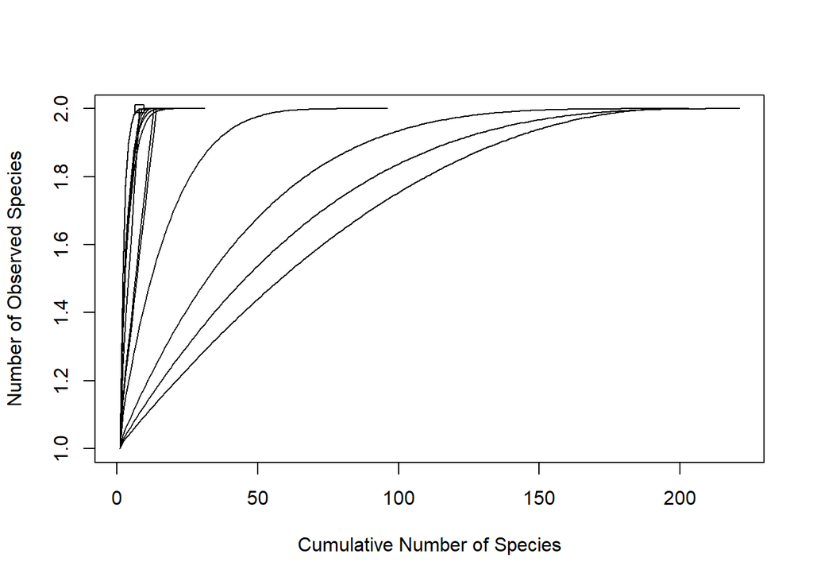

```r
#Create Data Table for Rarefy
Table_2 = data.frame(
  Number = c(1,2,3,4,5,6,7,8,9,10,11,12,13,14,15),
  Occurences = c(7,197,218,199,91,18,24,2,6,3,3,1,1,16,13)
)
#Rarefaction Curve from Vegan package
#Rarecurve(data, step size, labels )
rarecurve(Table_2, step = 1, xlab = "Cumulative Number of Species", ylab = "Number of Observed Species", label = TRUE)
```